# Intro to using GIS in Python

## How to work with GIS

Geographic information system (GIS) is a system to capture and analyse spatial and geographical data.

It is often divided into two types of data:

1. Vector data consisting of point, line (or arc), and polygon data. Polygon consists of geometries, which is formed of points. You may come across multipolygons, which are essentially multiple polygons grouped together.
2. Raster data consisting of continuous or discrete features of surfaces and areas, such as topological information, population density, or satellite imagery.

For the Transport Systems module, you will be working with the vector data.

Vector GIS data is commonly stored in the **shapefile** format with related attribute data. These can be opened by commercial software packages such as ArcGIS by ESRI, creator of shapefiles, or QGIS.

Whilst the term shapefile sounds like there would be one singular file, a shapefile is a collection of multiple basic files:

- *.shp - Main file (required) with the geometry data -- this often has the largest file size
- *.shx - Index file (required) with the geometry data index
- *.dbf - Attribute file (required) with the attribute information of features and geometry -- even with zero attributes, this is required.
- *.prj - The file that stores the coordinate system information (optional).
- *.cpg - The file that can be used to specify the codepage for identifying the character set to be used (optional).
- *.sbn - One of the two files that store spatial index of the features (optional).
- *.sbx - One of the two files that store spatial index of the features (optional).
- *.xml - Metadata for information about the shapefile (optional).

All the files that form one shapefile needs to have the same prefix, e.g. roads.shp, roads.shx, roads.dbf, etc.

When using Python to process shapefiles, we will read in *.shp file, but all the other required files need to be present in the same folder.

One more important aspect to consider when working with GIS data is ensuring you are working in the same coordinate reference system (CRS) throughout your entire project. In this course, we will be using EPSG:4326 (WGS 84). This is the latitude and longitude CRS you will find when you Google London's latitude and longitude: 51.509865, -0.118092. **However, shapefile geometry order is longitude then latitude.**

### Installation requirement

Now that we understand what the files are for, let's install and import the necessary packages for us to be able to work with shapefiles.

Within your conda environment `tsenv`, you will already have a few libraries installed from previous sessions:

- numpy
- pandas
- matplotlib
- scikit-learn (or sklearn)
- pulp

We will now install geopandas, which is pandas for geospatial data. To do this, we need to first ensure to install GDAL (Geospatial Data Abstraction Library), which is a translator library for raster and vector geospatial data formats.

Regardless of having a Windows or Mac or Linux operating system, instead of `pip install ..`, we will be using `conda install ..`:

`conda install -c conda-forge gdal`  
`conda install geopandas`

If this didn't work, especially for those of you, who are using Windows, try using an alternative method following a YouTube video [here](https://www.youtube.com/watch?v=LNPETGKAe0c).

*Please contact your GTAs, if you are having trouble installing GDAL and/or Geopandas.*

As part of the GeoPandas, a package called Shapely will be downloaded. This helps us work with GIS data of points, polygons, and multipolygons.

### Working with GeoPandas

Now, let's start coding.

```python
import numpy as np
import pandas as pd
import matplotlib.pyplot as plt
from shapely.geometry import Point, Polygon, MultiPolygon
import geopandas as gpd
from sklearn.cluster import KMeans
from matplotlib import cm
from pulp import *

%matplotlib inline
```

You can read in a shapefile the following way by refering to the *.shp file.

```python
ldn_df = gpd.read_file('LSOA_GreaterLondon_Households.shp')

ldn_df.head()
```

|  | LSOA11CD | LSOA11NM | HHOLDS | AVHHOLDSZ | geometry |
| --- | --- | --- | --- | --- | --- |
| 0 | E01000001 | City of London 001A | 876 | 1.7 | POLYGON ((-0.09726 51.52158, -0.09649 51.52028... |
| 1 | E01000002 | City of London 001B | 830 | 1.7 | POLYGON ((-0.08810 51.51941, -0.08927 51.51752... |
| 2 | E01000003 | City of London 001C | 817 | 1.5 | POLYGON ((-0.09676 51.52325, -0.09644 51.52282... |
| 3 | E01000005 | City of London 001E | 467 | 2.1 | POLYGON ((-0.07320 51.51000, -0.07551 51.50974... |
| 4 | E01000006 | Barking and Dagenham 016A | 543 | 3.1 | POLYGON ((0.09118 51.53909, 0.09328 51.53787, ... |

The example shapefile contains Lower Super Output Areas (LSOA) in Greater London. LSOAs are a geographic hierarchy designed to improve the reporting of small area statistics in England and Wales.

In this example, our shapefile contains the LSOA zone codes (or IDs), the name of the LSOAs, the number of households in each area and the average household size for each zone. Then most importantly, the data also contains the geometry details of the polygon, which forms the outline of each LSOA zone.

As mentioned, it is very important to note that the geometry in Geopandas is in order of longitude then latitude. If you get these mixed up, instead of analysing London, you may be analysing bits of the sea next to Somalia!

In previous sessions, you have already learned how to works with pandas dataframes. Geopandas dataframe are the same. We will make a graph using our new `ldn_df`. Latitude defines your y and longitutde defines your x.

We will use `matplotlib.pyplot` that has been imported as `plt` to plot the average household size of different LSOAs in London.

```python
# The following is optional. You can set any minimum x and y and maximum x and y for your plot frame.

minx, miny, maxx, maxy = ldn_df.total_bounds
```

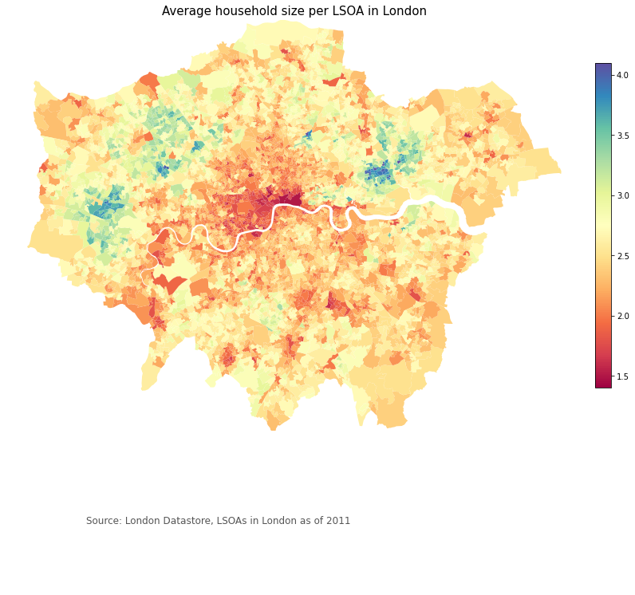

```python
fig, ax = plt.subplots(1, figsize = (15,15))

# I have calculated the minimum and maximum latitudes and longitudes, so that my graph has very little whitespace.
# This is optional. You could have more white space, but ensure, you show your entire graph
ax.set_xlim(minx, maxx)
ax.set_ylim(miny, maxy)


# add a title
ax.set_title('Average household size per LSOA in London', fontdict={'fontsize': '15', 'fontweight': '3'})

# We will remove the axis for better presentation
ax.axis('off')

# We will annotate and add source
ax.annotate('Source: London Datastore, LSOAs in London as of 2011',xy=(0.1, .08),  xycoords='figure fraction', horizontalalignment='left', verticalalignment='bottom', fontsize=12, color='#555555')

# Plot using a rainbow colormap
ldn_df.plot(ax=ax,alpha=1, column='AVHHOLDSZ', cmap='Spectral')

# Add colorbar
sm = plt.cm.ScalarMappable(cmap='Spectral', norm=plt.Normalize(vmin=ldn_df.AVHHOLDSZ.min(), vmax=ldn_df.AVHHOLDSZ.max()))# empty array for the data range
cbar = fig.colorbar(sm, shrink=0.5)
```

### Geometric centroids

(You won't need to calculate your own centroids in your coursework, but this is how you would normally calculate the geometric centroids.)

Now, let's try to calculate geometric centroids of each LSOA.

One crucial note about the CRS of EPSG:4326 (WGS84). EPSG stands for European Petroleum Survey Group and now known as Geomatics Committee of the International Association of Oil and Gas Producers. They have various coordinate reference systems, and the one used on Google Maps is EPSG:4326, which is the same as WGS84. WGS stands for World Geodetic System. As the name already gives away, WGS84 or EPSG:4326 is based on a geodetic plane, which takes the curvature of the earth into account. (Contrary to what some believe, the earth is not flat!)

However, to calculate a geometric centroid, we want to know the plane area of each LSOA. To do this, for UK, we can use the ETRS89 Lambert Azimuthal Equal Area projection to "flatten" the surface of Europe. ETRS stands for European Terrestrial Reference System and this projection was created in 1989. This is equivalent to EPSG:3035. Depending on your geographical location, you may have to use a different EPSG to "flatten" your geometry, especially if you are studying an area outside of Europe, as the earth is not a perfect sphere.

```python
# To convert the geometry
ldn_geo_3035 = ldn_df['geometry'].to_crs(epsg=3035)
ldn_geo_3035.head()
```

```
0    POLYGON ((3622752.020 3205175.179, 3622785.117...
1    POLYGON ((3623347.578 3204848.398, 3623238.782...
2    POLYGON ((3622812.179 3205354.940, 3622827.250...
3    POLYGON ((3624226.440 3203667.543, 3624064.363...
4    POLYGON ((3635952.960 3205319.919, 3636079.201...
Name: geometry, dtype: geometry
```

You can see the polygon data is no longer in WGS84 format. Now the earth is flat, we can calculate the centroids.\

(You may come across a tempting funtion called `GeoSeries.representative_point()`. This is **not** the centroid, but just a very quick method of finding an *arbitrary* point in a polygon. This will give you the wrong result!)

```python
ldn_geo_3035_centroids = ldn_geo_3035.centroid

ldn_geo_3035_centroids.head()
```

```
0    POINT (3622732.366 3204776.166)
1    POINT (3623025.554 3204758.729)
2    POINT (3622855.564 3205177.114)
3    POINT (3624103.524 3204083.299)
4    POINT (3635765.214 3205333.478)
dtype: geometry
```

Now, we need to convert back to EPSG:4326.

```python
ldn_geo_4326_centroids = ldn_geo_3035_centroids.to_crs(epsg=4326)
ldn_geo_4326_centroids.head()
```

```
0    POINT (-0.09675 51.51801)
1    POINT (-0.09253 51.51822)
2    POINT (-0.09579 51.52172)
3    POINT (-0.07578 51.51355)
4     POINT (0.08847 51.53898)
dtype: geometry
```

```python
centroids = gpd.GeoSeries(ldn_geo_4326_centroids, name='centroids')
```

Great! We now have a GeoSeries of the centroids. Let's now merge it with our original GeoPandas dataframe.

```python
ldn_df = ldn_df.merge(centroids,left_index=True, right_index=True)

ldn_df.head()
```

|  | LSOA11CD | LSOA11NM | HHOLDS | AVHHOLDSZ | geometry | centroids |
| --- | --- | --- | --- | --- | --- | --- |
| 0 | E01000001 | City of London 001A | 876 | 1.7 | POLYGON ((-0.09726 51.52158, -0.09649 51.52028... | POINT (-0.09675 51.51801) |
| 1 | E01000002 | City of London 001B | 830 | 1.7 | POLYGON ((-0.08810 51.51941, -0.08927 51.51752... | POINT (-0.09253 51.51822) |
| 2 | E01000003 | City of London 001C | 817 | 1.5 | POLYGON ((-0.09676 51.52325, -0.09644 51.52282... | POINT (-0.09579 51.52172) |
| 3 | E01000005 | City of London 001E | 467 | 2.1 | POLYGON ((-0.07320 51.51000, -0.07551 51.50974... | POINT (-0.07578 51.51355) |
| 4 | E01000006 | Barking and Dagenham 016A | 543 | 3.1 | POLYGON ((0.09118 51.53909, 0.09328 51.53787, ... | POINT (0.08847 51.53898) |

Let's show these centroids in our original plot.

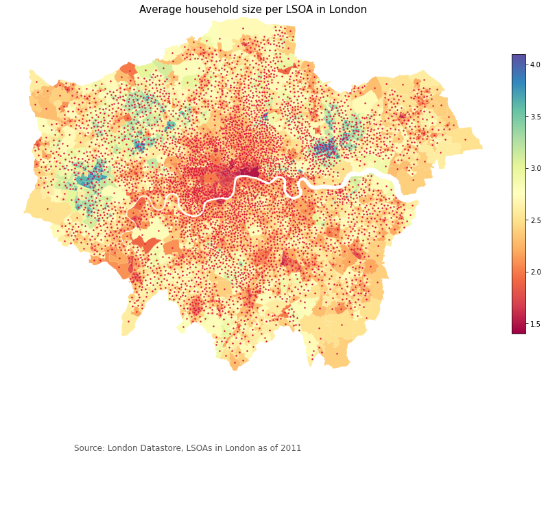

```python
fig, ax = plt.subplots(1, figsize = (15,15))

ax.set_xlim(minx, maxx)
ax.set_ylim(miny, maxy)

# add a title
ax.set_title('Average household size per LSOA in London', fontdict={'fontsize': '15', 'fontweight': '3'})

# We will remove the axis for better presentation
ax.axis('off')

# We will annotate and add source
ax.annotate('Source: London Datastore, LSOAs in London as of 2011',xy=(0.1, .08),  xycoords='figure fraction', horizontalalignment='left', verticalalignment='bottom', fontsize=12, color='#555555')

# Plot using a rainbow colormap
ldn_df.plot(ax=ax,alpha=1, column='AVHHOLDSZ', cmap='Spectral')

# Add colorbar
sm = plt.cm.ScalarMappable(cmap='Spectral', norm=plt.Normalize(vmin=ldn_df.AVHHOLDSZ.min(), vmax=ldn_df.AVHHOLDSZ.max()))# empty array for the data range
cbar = fig.colorbar(sm, shrink=0.5)

ldn_df['centroids'].plot(ax=ax, markersize=2, color='crimson',marker='o'); # The semicolon is to suppress output info.
```

### Connecting centroids

Now that we have the centroids, imagine one of them connected to some of the other centroids. How can we visualise this on a plot?

First, we will choose a main centroid arbitrarily to connect to some randomly selected others. In your assignment, you need to connect your facility locations to the relevant centroids.

```python
import random

n_random_centroids = 50

centroid_main = {'main': random.choice(ldn_df['centroids'])}
centroid_set_random = dict(zip(list('pt' + str(i+1) for i in range(n_random_centroids)), random.choices(ldn_df['centroids'], k=n_random_centroids)))
```

We will now connect `centroid_random` to other points in `centroid_set_random`.

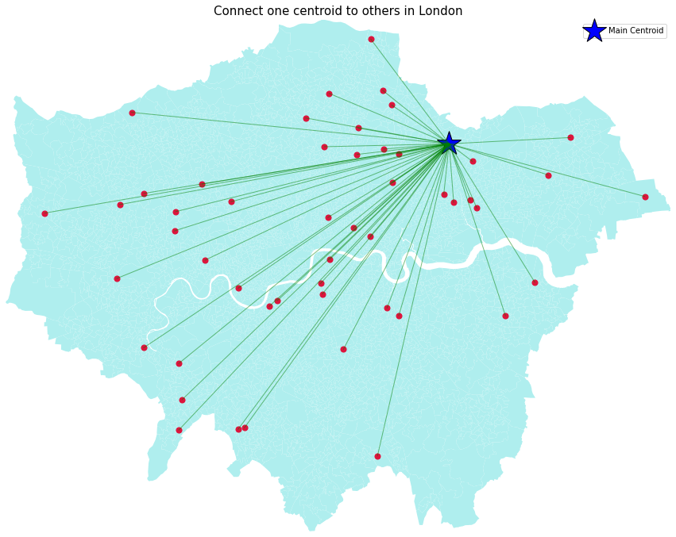

```python
fig, ax = plt.subplots(1, figsize = (15,15))
ax.axes.set_aspect('equal')

ax.set_xlim(minx, maxx)
ax.set_ylim(miny, maxy)
# In your assignment, you may want to zoom into your relevant areas and change your plot frame.

# add a title
ax.set_title('Connect one centroid to others in London', fontdict={'fontsize': '15', 'fontweight': '3'})

# We will remove the axis for better presentation
ax.axis('off')

# Plot the base map of London with the LSOA
ldn_df.plot(ax=ax, alpha=1, color='paleturquoise')

# Plot the main centroid chosen before
for k1,v1 in centroid_main.items():
    ax.scatter(x=v1.x, y=v1.y, s=1000, color='blue', marker='*', edgecolor='black', label='Main Centroid')

# Plot the chosen set of centroids
for k2,v2 in centroid_set_random.items():
    ax.scatter(x=v2.x, y=v2.y, s=50, color='crimson', marker='o')

# Connect the random single centroid with the other chosen centroids
for k1,v1 in centroid_main.items():
    for k2,v2 in centroid_set_random.items():
        ax.plot([v1.x, v2.x],[v1.y,v2.y],
                color='green',alpha=0.5, linewidth=1)

# plt.axis('scaled')
legend = ax.legend()
```

### How to calculate the distance between two points on earth.

We need to also learn to calculate the distance between two points on a map. You cannot take the Euclidean distance for such long distances and we need to take the earth's arc into account.

The following function will be useful to calculate the distance between two point using the haversine formula based on the radius of the earth at the latitude of London, 6365.078 km. The radius of the earth varies from 6356.752 km at the poles to 6378.137 km at the equator.

```python
def haversine_np(lon1, lat1, lon2, lat2):
    """
    Calculate the great circle distance between two points
    on the earth (specified in decimal degrees)

    """

    r_earth = 6365.078
    lon1, lat1, lon2, lat2 = map(np.radians, [lon1, lat1, lon2, lat2])

    dlon = lon2 - lon1
    dlat = lat2 - lat1

    a = np.sin(dlat/2.0)**2 + np.cos(lat1) * np.cos(lat2) * np.sin(dlon/2.0)**2

    c = 2 * np.arcsin(np.sqrt(a))
    km = r_earth * c
    return km
```

Let's test the `haversine_np` function with our main centroid with the 2nd random centroid from our set.

```python
dist = haversine_np(centroid_main['main'].x, centroid_main['main'].y, centroid_set_random['pt2'].x, centroid_set_random['pt2'].y)
print(f'Distance between the two points are {np.round(dist,2)} km.')
```

```
Distance between the two points are 15.91 km.
```

### Creating a coverage matrix

We have 1 main centroid and 50 random centroids. However, out of the 50, let's say, I want to only select those within 15km. How will I find those that are *covered* within the 15km radius?

Using the Haversine distance calculator `haversine_np` from above, we will first create a distance dictionary from the main centroid to others in the set.

```python
dist_dict = {}
for k1, v1 in centroid_main.items():
    for k2, v2 in centroid_set_random.items():
        dist_dict[(k1,k2)] = haversine_np(v1.x,v1.y,v2.x,v2.y)
```

We now want to create a new matrix where the value is 1, if a centroid from our set is within 15km of our main centroid. In Python, the matrix is in the form of a nested dictionary. This means that the dictionary has a key of the facility location and value with another dictionary of the delivery locations and the values of 1 to confirm coverage. For example,

```
coverage_matrix = {'facility1': {'A1':1, 'A3':1, 'A5':1},
                    'facility2': {'A2':1, 'A5':1},
                    'facility3': {'A1':1, 'A2':1, 'A3':1, 'A4':1}}
```

See [Notebook 3.8](https://transport-systems.imperial.ac.uk/tf/60008_21/n3_8_covering_problem.html).

```python
max_distance = 15
coverage_matrix = {}
for k1, v1 in centroid_main.items():
    coverage_matrix[k1] = {}
    for k2, v2 in centroid_set_random.items():
        if dist_dict[(k1,k2)] <= max_distance:
            coverage_matrix[k1][k2] = 1
```

Now let's plot the covered centroids in a different colour and only connect these to the main centroid.

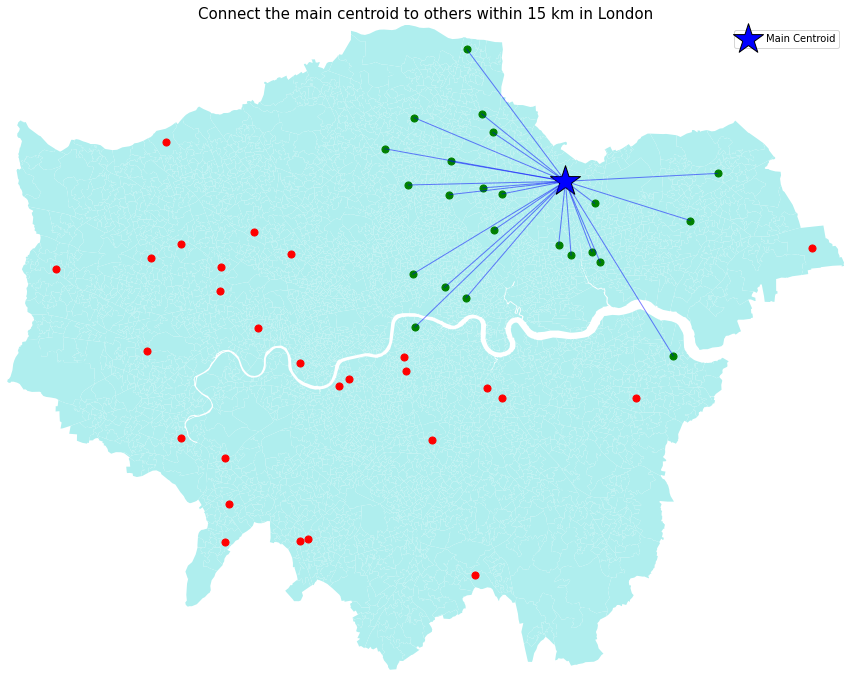

```python
fig, ax = plt.subplots(1, figsize = (15,15))
ax.axes.set_aspect('equal')

ax.set_xlim(minx, maxx)
ax.set_ylim(miny, maxy)
# In your assignment, you may want to zoom into your relevant areas and change your plot frame.

# add a title
ax.set_title('Connect the main centroid to others within 15 km in London', fontdict={'fontsize': '15', 'fontweight': '3'})

# We will remove the axis for better presentation
ax.axis('off')

# Plot the base map of London with the LSOA
ldn_df.plot(ax=ax, alpha=1, color='paleturquoise')

# Plot the main centroid chosen before
for k1,v1 in centroid_main.items():
    ax.scatter(x=v1.x, y=v1.y, s=1000, color='blue', marker='*', edgecolor='black', label='Main Centroid')

# Plot the chosen set of centroids
for k1,v1 in centroid_main.items():
    for k2,v2 in centroid_set_random.items():
        if k2 in coverage_matrix[k1]:
            ax.scatter(x=v2.x, y=v2.y, s=50, color='green', marker='o')
        else:
            ax.scatter(x=v2.x, y=v2.y, s=50, color='red', marker='o')

# Connect the random single centroid with the other chosen centroids
for k1,v1 in centroid_main.items():
    for k2,v2 in centroid_set_random.items():
        if k2 in coverage_matrix[k1]:
            ax.plot([v1.x, v2.x],[v1.y,v2.y], color='blue',alpha=0.5, linewidth=1)

# plt.axis('scaled')
legend = ax.legend()
```